# Building Bricks Of Colour Clustering

### 2.3.2 PAM Clustering on CIELAB Values

#### Search for Optimal $k$ `labInfo`

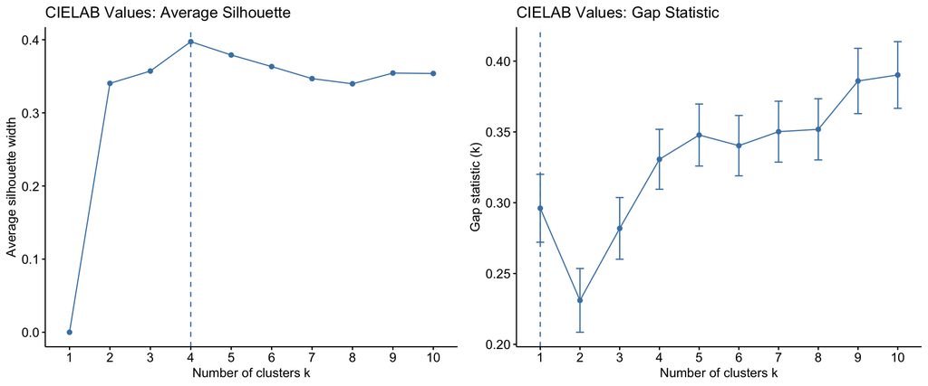

```r
set.seed(seed)


labInfo_sil <- fviz_nbclust(labInfo,
                           FUNcluster = pam,
                           method = c("silhouette"),
                           k.max = 10) +
  ggplot2::ggtitle("CIELAB Values: Average Silhouette")

labInfo_gap <- fviz_nbclust(labInfo,
                           FUNcluster = pam,
                           method = c("gap_stat"),
                           k.max = 10) +
  ggplot2::ggtitle("CIELAB Values: Gap Statistic")

labInfo_k <- pamk(labInfo,
                 krange = 3:10)

gridExtra::grid.arrange(labInfo_sil, labInfo_gap, ncol = 2)
```

Optimal number of clusters for `labInfo` dataset: 4

#### PAM clustering and Basic statistics

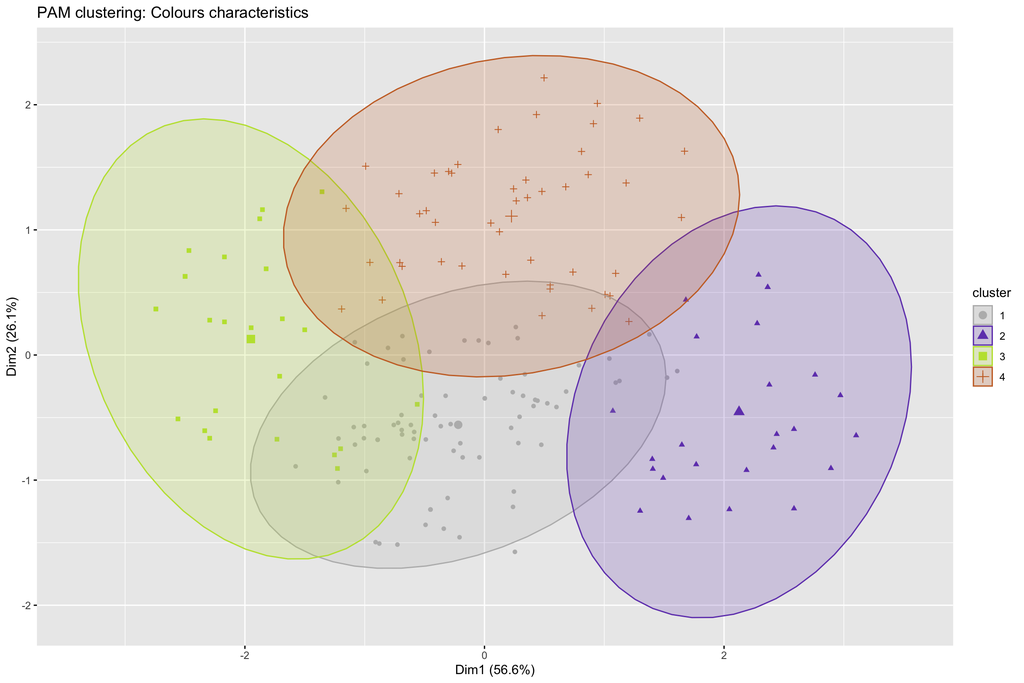

```r
labInfo_pam <- pam(labInfo, labInfo_k$nc)

p_labInfo <- fviz_cluster(labInfo_pam, data = labInfo,
             geom = "point",
             ellipse.type = "norm",
             show.clust.cent = TRUE,
             palette = bricklink$hexNumber[labInfo_pam$id.med],
             main = "PAM clustering: Colours characteristics")

p_labInfo
```

```r
labInfo_pam_kcca <- flexclust::as.kcca(labInfo_pam, labInfo)
pLabInfoStripes <- grid.grabExpr(stripes(labInfo_pam_kcca, col = bricklink$hexNumber[labInfo_pam$id.med]))
pLabInfoSil <- fviz_silhouette(labInfo_pam, palette = bricklink$hexNumber[labInfo_pam$id.med])
```

```
##   cluster size ave.sil.width
## 1       1   78          0.40
## 2       2   26          0.46
## 3       3   25          0.37
## 4       4   47          0.37
```

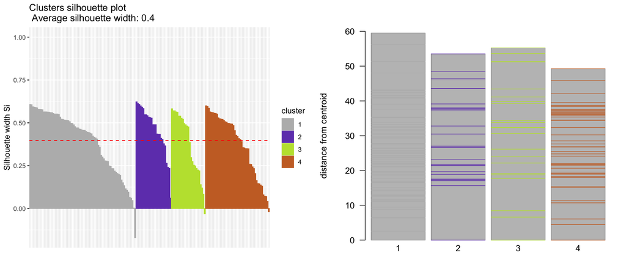

```r
gridExtra::grid.arrange(pLabInfoSil, pLabInfoStripes, ncol = 2)
```

#### Colours Swatches for Partition

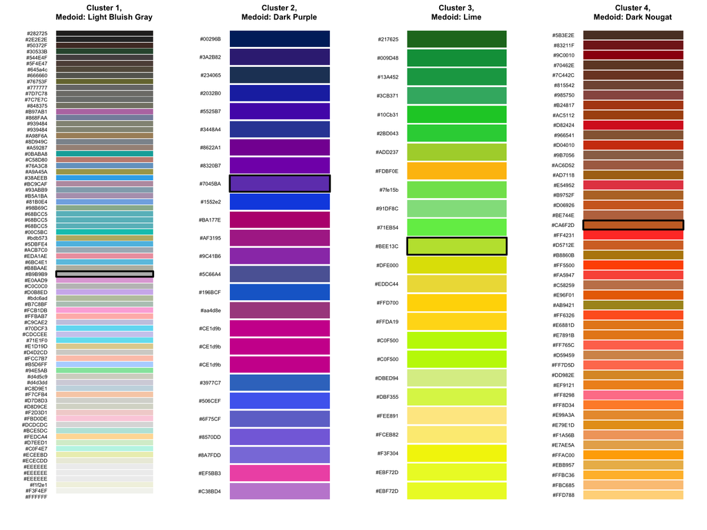

```r
par(mfrow = c(1, length(labInfo_pam$id.med)), fg = NA)

for (i in seq_along(labInfo_pam$id.med)) {
  cols <- setNames(bricklink$hexNumber, make.unique(as.character(bricklink$name)))[names(which(labInfo_pam$clustering == i))]
  cols <- cols[order(farver::decode_colour(cols, to = "lab")[, "l"])]

  swatch(cols)
  title(main = paste0("Cluster ", i, ",\nMedoid: ", rownames(labInfo_pam$medoids)[i]),
        line = -1)

  pos <- which(names(rev(cols)) == rownames(labInfo_pam$medoids)[i])
  rect(0, (pos - 1) * 1.1 + 0.1, 1, pos * 1.1, border = "black", lwd = 3, xpd = TRUE)
}

par(old_par)
```

### 2.3.3 Interpretation of the Visual Clusters

Partitioning based on CIELAB values grouped LEGO colours into 4 colour groups, with an average silhouette width of $0.40$. The clusters are as follows:

- **Cluster 1: LOWCHROMA** (Medoid: Light Bluish Gray):
  - The largest cluster, spanning the full lightness ($L^*$) spectrum from near-black through desaturated colours to pure white. Captures low-chroma colours clustered near the central neutral axis of CIELAB space.
- **Cluster 2: SPACE** (Medoid: Dark Purple):
  - Groups cool tones, ranging from deep navy blues to light violets and magentas. Occupies the negative-$b^*$ region of the perceptual colour space.
- **Cluster 3: CITRUS** (Medoid: Lime):
  - Mainly bright greens and lime shades with a selection of different yellows. Covers the positive-$b^*$, negative-to-neutral-$a^*$ quadrant.
- **Cluster 4: AUTUMN** (Medoid: Dark Nougat):
  - Collects warm earth tones and bright reds, second largest of the clusters with wide range of browns, red, oranges with some pink accents. Occupies the positive-$a^*$, positive-$b^*$ quadrant.

An average silhouette width of $0.40$ reflects moderate cluster separation, which aligns with the continuous nature of human colour perception—colours transition smoothly along lightness and hue gradients rather than forming isolated islands. Despite the blurry boundaries seen in the VAT matrix, PAM partitions the LEGO palette along clear perceptual lines. The resulting partition with medoids: *Light Bluish Gray*, *Dark Purple*, *Lime*, and *Dark Nougat* forms a balanced, high-contrast representative palette for the image recolouring stage.

## 2.4 Comparing Market and Visual Partitions

To finish this chapter, let’s compare how similar or different the two partitions are. To inspect this, three metrics are calculated:

- **Adjusted Mutual Information (AMI):** A measure quantifying the shared information between partitions $C_1$ and $C_2$, adjusted for chance agreement (Vinh et al., 2010):

  $$\text{AMI}(C_1, C_2) = \frac{I(C_1, C_2)
  - E\big[I(C_1, C_2)\big]}{\frac{1}{2}\big[H(C_1) + H(C_2)\big] -
  E\big[I(C_1, C_2)\big]}$$
  - $I(C_1, C_2)$: Mutual Information between $C_1$ and $C_2$.
  - $H(C_1), H(C_2)$: Shannon entropies of the cluster distributions in $C_1$ and $C_2$.
  - $E\big[I(C_1, C_2)\big]$: Expected Mutual Information between two random partitions with the same cluster sizes under a hypergeometric model.
- **Adjusted Rand Index (ARI):** A measure evaluating agreement across both co-assigned and separated pairs, corrected for chance:

  $$\text{ARI}(C_1, C_2) = \frac{a -
  \frac{(a + b)(a + c)}{\binom{N}{2}}}{\frac{1}{2}\big[(a + b) + (a +
  c)\big] - \frac{(a + b)(a + c)}{\binom{N}{2}}}$$
  - $a, b, c$: Pair counts defined identically to the Jaccard Index in subsection 2.2.6.
  - $\binom{N}{2} = \frac{N(N - 1)}{2}$: Total number of distinct observation pairs across all $N$ colours.
- **Jaccard Index:** Introduced in subsection 2.2.6 to evaluate cluster stability with bootstrapping.

To note*: As there is unequal number of clusters ($k_{marketTrans} = 5$ and $k_{labInfo} = 4$) one-to-one correspondence between partitions is formally impossible. Consequently, none of the three metrics can reach the maximum of $1$. While AMI and ARI account for the unequal number of cluster counts with chance-correction terms, the standard Jaccard Index penalises this difference directly, as it shrinks the value of co-assigned pairs ($a$), and inflates different pairs ($b$ or $c$), resulting in structurally lower values.

```r
bricklink$marketCluster <- factor(marketTrans_pam$clustering,
                                  labels = c("UNIQUES",
                                             "STAPLES",
                                             "NEW LEADERS",
                                             "NOVELTIES",
                                             "MISCELLANEOUS"))
bricklink$CIELABCluster <- factor(labInfo_pam$clustering,
                                  labels = c("LOWCHROMA",
                                             "SPACE",
                                             "CITRUS",
                                             "AUTUMN"))

market_clusters <- bricklink$marketCluster
visual_clusters <- bricklink$CIELABCluster
```

```r
knitr::kable(
  addmargins(table(Market = market_clusters, Visual = visual_clusters)),
  caption = "Contingency Table of LEGO Colours Across Market and Visual Clusters"
)
```

Contingency Table of LEGO Colours Across Market and Visual Clusters

|  | LOWCHROMA | SPACE | CITRUS | AUTUMN | Sum |
| --- | --- | --- | --- | --- | --- |
| UNIQUES | 31 | 11 | 5 | 16 | 63 |
| STAPLES | 10 | 2 | 3 | 3 | 18 |
| NEW LEADERS | 17 | 4 | 3 | 5 | 29 |
| NOVELTIES | 13 | 5 | 8 | 14 | 40 |
| MISCELLANEOUS | 7 | 4 | 6 | 9 | 26 |
| Sum | 78 | 26 | 25 | 47 | 176 |

```r
knitr::kable(
  data.frame(
    Metric = c("Adjusted Mutual Information (AMI)", "Adjusted Rand Index (ARI)","Jaccard Index"),
    Value  = round(c(aricode::AMI(market_clusters, visual_clusters),
      flexclust::comPart(market_clusters, visual_clusters, type = c("ARI", "J"))
    ), 4)
  ),
  row.names = FALSE,
  caption = "Agreement Between Market (k = 5) and Visual (k = 4) Partitions"
)
```

Agreement Between Market (k = 5) and Visual (k = 4) Partitions

| Metric | Value |
| --- | --- |
| Adjusted Mutual Information (AMI) | 0.0027 |
| Adjusted Rand Index (ARI) | 0.0118 |
| Jaccard Index | 0.1590 |

All three metrics confirm that clustering LEGO colours by market and visual characteristics produces fundamentally different partitions. Even accounting for the structural limitation of different numbers of clusters $k_{marketTrans} \neq k_{labInfo}$, both AMI and ARI metrics indicate independence between colours’ market dynamics and visual information. The Jaccard Index yields the highest value of the three metrics mainly because the two largest clusters from both partitions share 31 colours.

## 2.5 Conclusions

The performed analyses allow us to address the stated hypotheses:

> H3: As shown in the case of the `market` dataset, using raw skew data with different scales lead to the creation of uneven clusters.

> H4a & H4b: Both market (after appropriate transformations) and visual characteristics produced clusters that revealed market bins and coherent colour palettes.

> H5: Market and visual clusters proved to be independent, with low agreement between the two partitions.

The analyses in this chapter showed that clustering algorithms could be used for investigating real market dynamics and creating colour palettes coherent within each other with distinct chroma and hue values. This proves the diversity in the usage of PAM and how it may give insight into different types of data.

The five market clusters and four visual clusters are carried forward as restrictive palettes for the LEGO set recolouring experiment in Chapter 3

# Chapter 3: Recolouring LEGO Sets

The cluster analysis of the LEGO colours dataset available on the BrickLink website provided insight into the dynamics of the second-hand LEGO marketplace and perceptual colour values available within the LEGO colour palette.

This chapter is an experimental study of how cluster analysis can be useful in creating alternative colour-variants of existing LEGO sets. Each cluster from the two partitionings based on market and visual characteristics can be treated as a restrictive colour palette for building a LEGO set.

Envision yourself in two positions:

1. For partion on **Market Characteristic**: You are *a LEGO collector*, trying to reconstruct your favourite LEGO set with colours based on their membership to different market groups.
2. For partion on **Visual Characteristic**: You are *a LEGO designer*, with a task to re-design an existing LEGO product into a new theme and have to match the theme colour palette.

Using image segmentation for the perceptual colour space and the given restrictive palette, we may illustrate the possible work result of *a LEGO collector* and *a LEGO designer*.

Methodology for this chapter:

- Select the image segmentation performed in the CIELAB colour-space from Section 1.3 {LegoSet}.
- Select a colour palette based on the clusters from Chapter 2 {Palette}.
- Map {Palette} onto the medoids of {LegoSet}. To map the {Palette}, calculate the $\Delta E_{00}$ between each colour in the {Palette} and each medoid of {LegoSet}. For each medoid, choose the closest colour from the {Palette}.<sup>1,2</sup>
- Re-construct the image using {LegoSet} with the new colours chosen from {Palette}

Annotation 1: To account for ‘The White Background Issue’, the white medoid included in each {LegoSet} partition will be fixed and no new colour will be mapped onto it.

Annotation 2: Naive approach is applied here, but it should be noted that there is a chance that one colour from the palette is chosen to be mapped onto two different medoids.

## 3.1 Preparation and Preview of Cluster Palettes

```r
marketPalettes <- split(bricklink, bricklink$marketCluster)
CIELABPalettes <- split(bricklink, bricklink$CIELABCluster)
```

### Palettes from Market Characteristics

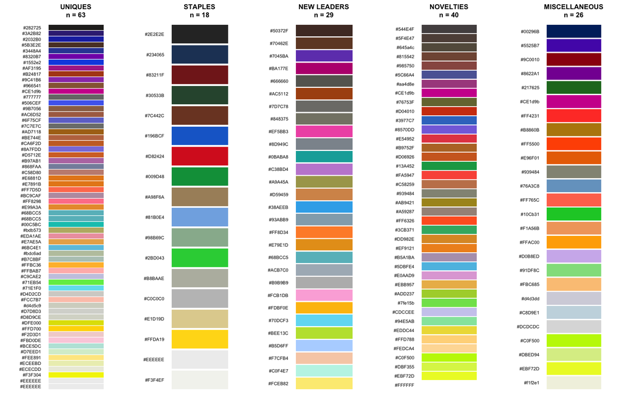

```r
par(mfrow = c(1, length(marketPalettes)), fg = NA)

for (x in names(marketPalettes)) {
  pal <- marketPalettes[[x]]
  swatch(pal$hexNumber[order(pal$l)])
  title(main = paste0(x, "\nn = ", nrow(pal)),
        line = -1)}

par(old_par)
```

### Palettes from Visual Characteristics

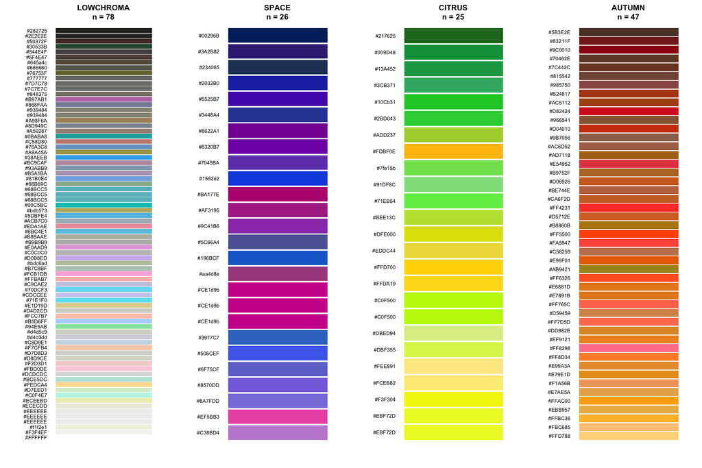

```r
par(mfrow = c(1, length(CIELABPalettes)), fg = NA)

for (x in names(CIELABPalettes)) {
  pal <- CIELABPalettes[[x]]
  swatch(pal$hexNumber[order(pal$l)])
  title(main = paste0(x, "\nn = ", nrow(pal)),
        line = -1)}

par(old_par)
```

## 3.2 Preparation of Recolouring Algorithm

```r
chooseNewMedoidsColours <- function(imgCLARA, palette){
  imgMedoids <- imgCLARA$medoids
  dist_mat <- compare_colour(imgMedoids,
                             as.matrix(palette[, c("l", "a", "b")]),
                             from_space = "lab",
                             method = "cie2000")

  new_hex <- palette$hexNumber[apply(dist_mat,
                                     1,
                                     which.min)]

  # if original cluster included white and it is not already present in new_hex-> add white
  if (max(imgMedoids[, "l"]) > 98 && !("#FFFFFF" %in% new_hex)) {
  new_hex[which.max(imgMedoids[, "l"])] <- "#FFFFFF"
}

  return(new_hex)
}

applyNewColours <- function(img, imgCLARA, palette) {

  dm1 <- dim(img)
  newMedoids <- chooseNewMedoidsColours(imgCLARA, palette)
  result <- matrix(newMedoids[imgCLARA$clustering], nrow = dm1[1], ncol = dm1[2])

  return(result)
}

plotNewColours <- function(img, imgCLARA, palette, label = NULL) {
  recoloured <- applyNewColours(img, imgCLARA, palette)

  plot.new()
  plot.window(xlim = c(0, ncol(recoloured)),
              ylim = c(0, nrow(recoloured)),
              asp = 1,
              xaxs = "i",
              yaxs = "i")

  rasterImage(recoloured, 0, 0, ncol(recoloured), nrow(recoloured))

  mtext(label, side = 3, line = 0, cex = 0.85, font = 1)
}
```

## 3.3 LEGO Sets Reconstructed with Restrictive Palettes

Each set tab shows the baseline CIELAB segmentation at the top, followed by sub-tabs comparing the five market palettes and four visual palettes alongside their mapped HEX swatches.

### Seaside House 7346-1

[figure not shown]

```r
par(mfrow = c(1, 2))
plot.new()
plot.window(xlim = c(0, ncol(seasideHouse_paint$CIELAB)),
            ylim = c(0, nrow(seasideHouse_paint$CIELAB)),
            asp = 1,
            xaxs = "i",
            yaxs = "i")
rasterImage(seasideHouse_paint$CIELAB, 0, 0, ncol(seasideHouse_paint$CIELAB), nrow(seasideHouse_paint$CIELAB))
mtext("Original Image Segmented\n in CIELAB colourspace", side = 3, line = 0, cex = 1, font = 2)

swatch(seasideHouse_HEX$CIELAB)
mtext("Colours of original medoids", side = 3, line = -1, cex = 1, font = 2)
par(old_par)
```

#### Market Palettes

[figure not shown]

```r
graphics::layout(rbind(c(1, 3, 5),
                       c(2, 4, 6),
                       c(7, 9, 0),
                       c(8, 10, 0)),
                 heights = c(5, 1.5, 5, 1.5))

for (palette in names(marketPalettes)) {
  par(mar = c(0.2, 0.4, 3.8, 0.4))

  plotNewColours(seasideHouse,
                 seasideHouse_CLARA$CIELAB,
                 marketPalettes[[palette]],
                 label = paste0("Market-", palette, " palette"))

  cols <- chooseNewMedoidsColours(seasideHouse_CLARA$CIELAB, marketPalettes[[palette]])
  par(mar = c(3.8, 0.4, 0.2, 0.4))
  barplot(rep(1, length(cols)),
          col = cols,
          names.arg = cols,
          space = 0,
          border = NA,
          axes = FALSE,
          cex.names = 0.8)
}

graphics::layout(1)
par(old_par)
```

#### Visual Palettes

[figure not shown]

```r
graphics::layout(rbind(c(1, 3),
                       c(2, 4),
                       c(5, 7),
                       c(6, 8)),
                 heights = c(5, 1.5, 5, 1.5))

for (palette in names(CIELABPalettes)) {
  par(mar = c(0.2, 0.4, 3.8, 0.4))

  plotNewColours(seasideHouse,
                 seasideHouse_CLARA$CIELAB,
                 CIELABPalettes[[palette]],
                 label = paste0("Visual-", palette, " palette"))

  cols <- chooseNewMedoidsColours(seasideHouse_CLARA$CIELAB, CIELABPalettes[[palette]])
  par(mar = c(3.8, 0.4, 0.2, 0.4))
  barplot(rep(1, length(cols)),
          col = cols,
          names.arg = cols,
          space = 0,
          border = NA,
          axes = FALSE,
          cex.names = 0.8)
}

graphics::layout(1)
par(old_par)
```

### Cole’s Titan Dragon Mech 71821-1

[figure not shown]

```r
par(mfrow = c(1, 2))
plot.new()
plot.window(xlim = c(0, ncol(dragonMech_paint$CIELAB)),
            ylim = c(0, nrow(dragonMech_paint$CIELAB)),
            asp = 1,
            xaxs = "i",
            yaxs = "i")
rasterImage(dragonMech_paint$CIELAB, 0, 0, ncol(dragonMech_paint$CIELAB), nrow(dragonMech_paint$CIELAB))
mtext("Original Image Segmented\n in CIELAB colourspace", side = 3, line = 0, cex = 1, font = 2)

swatch(dragonMech_HEX$CIELAB)
mtext("Colours of original medoids", side = 3, line = -1, cex = 1, font = 2)
par(old_par)
```

#### Market Palettes

[figure not shown]

```r
graphics::layout(rbind(c(1, 3, 5),
                       c(2, 4, 6),
                       c(7, 9, 0),
                       c(8, 10, 0)),
                 heights = c(5, 1.5, 5, 1.5))

for (palette in names(marketPalettes)) {
  par(mar = c(0.2, 0.4, 3.8, 0.4))

  plotNewColours(dragonMech,
                 dragonMech_CLARA$CIELAB,
                 marketPalettes[[palette]],
                 label = paste0("Market-", palette, " palette"))

  cols <- chooseNewMedoidsColours(dragonMech_CLARA$CIELAB, marketPalettes[[palette]])
  par(mar = c(3.8, 0.4, 0.2, 0.4))
  barplot(rep(1, length(cols)),
          col = cols,
          names.arg = cols,
          space = 0,
          border = NA,
          axes = FALSE,
          cex.names = 0.8)
}

graphics::layout(1)
par(old_par)
```

#### Visual Palettes

[figure not shown]

```r
graphics::layout(rbind(c(1, 3),
                       c(2, 4),
                       c(5, 7),
                       c(6, 8)),
                 heights = c(5, 1.5, 5, 1.5))

for (palette in names(CIELABPalettes)) {
  par(mar = c(0.2, 0.4, 3.8, 0.4))

  plotNewColours(dragonMech,
                 dragonMech_CLARA$CIELAB,
                 CIELABPalettes[[palette]],
                 label = paste0("Visual-", palette, " palette"))

  cols <- chooseNewMedoidsColours(dragonMech_CLARA$CIELAB, CIELABPalettes[[palette]])
  par(mar = c(3.8, 0.4, 0.2, 0.4))
  barplot(rep(1, length(cols)),
          col = cols,
          names.arg = cols,
          space = 0,
          border = NA,
          axes = FALSE,
          cex.names = 0.8)
}

graphics::layout(1)
par(old_par)
```

### Wildflower Bouquet 10313-1

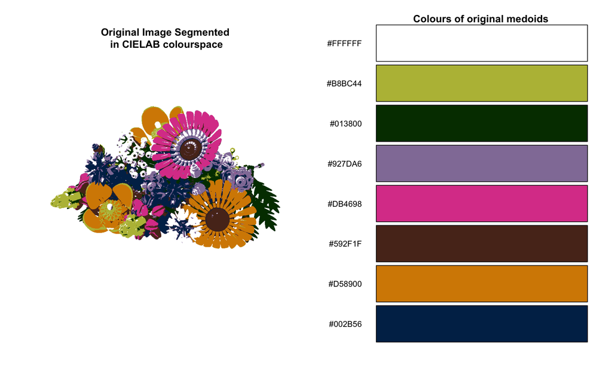

```r
par(mfrow = c(1, 2))
plot.new()
plot.window(xlim = c(0, ncol(flowers_paint$CIELAB)),
            ylim = c(0, nrow(flowers_paint$CIELAB)),
            asp = 1,
            xaxs = "i",
            yaxs = "i")
rasterImage(flowers_paint$CIELAB, 0, 0, ncol(flowers_paint$CIELAB), nrow(flowers_paint$CIELAB))
mtext("Original Image Segmented\n in CIELAB colourspace", side = 3, line = 0, cex = 1, font = 2)

swatch(flowers_HEX$CIELAB)
mtext("Colours of original medoids", side = 3, line = -1, cex = 1, font = 2)
par(old_par)
```

#### Market Palettes

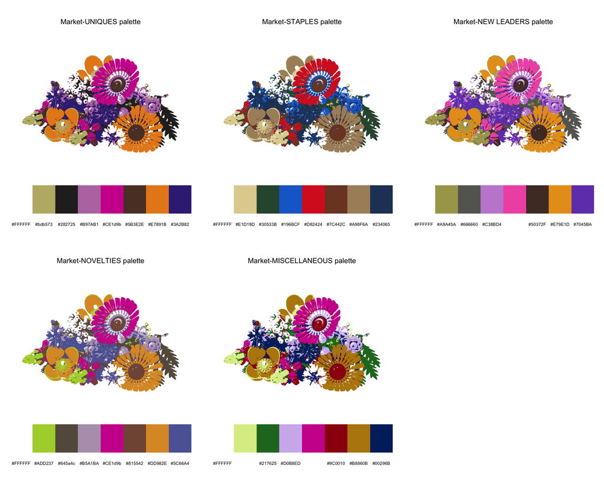

```r
graphics::layout(rbind(c(1, 3, 5),
                       c(2, 4, 6),
                       c(7, 9, 0),
                       c(8, 10, 0)),
                 heights = c(5, 1.5, 5, 1.5))

for (palette in names(marketPalettes)) {
  par(mar = c(0.2, 0.4, 3.8, 0.4))

  plotNewColours(flowers,
                 flowers_CLARA$CIELAB,
                 marketPalettes[[palette]],
                 label = paste0("Market-", palette, " palette"))

  cols <- chooseNewMedoidsColours(flowers_CLARA$CIELAB, marketPalettes[[palette]])
  par(mar = c(3.8, 0.4, 0.2, 0.4))
  barplot(rep(1, length(cols)),
          col = cols,
          names.arg = cols,
          space = 0,
          border = NA,
          axes = FALSE,
          cex.names = 0.8)
}

graphics::layout(1)
par(old_par)
```

#### Visual Palettes

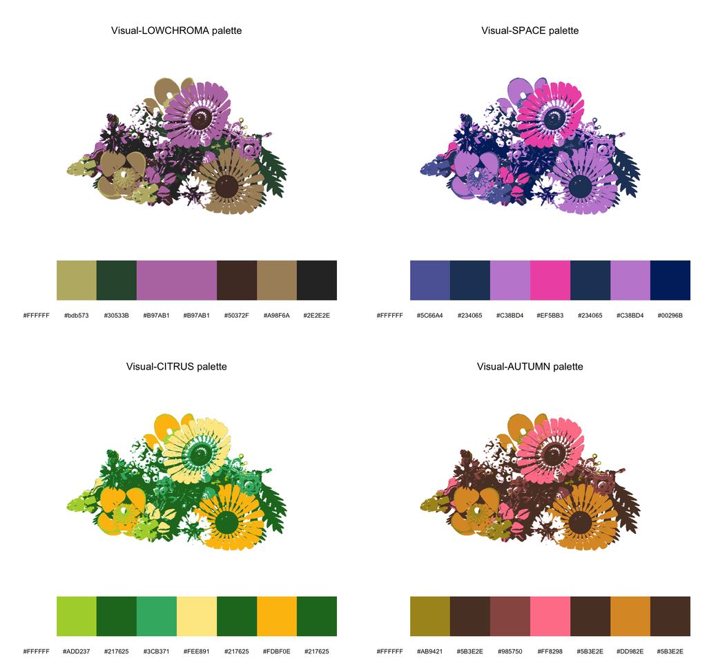

```r
graphics::layout(rbind(c(1, 3),
                       c(2, 4),
                       c(5, 7),
                       c(6, 8)),
                 heights = c(5, 1.5, 5, 1.5))

for (palette in names(CIELABPalettes)) {
  par(mar = c(0.2, 0.4, 3.8, 0.4))

  plotNewColours(flowers,
                 flowers_CLARA$CIELAB,
                 CIELABPalettes[[palette]],
                 label = paste0("Visual-", palette, " palette"))

  cols <- chooseNewMedoidsColours(flowers_CLARA$CIELAB, CIELABPalettes[[palette]])
  par(mar = c(3.8, 0.4, 0.2, 0.4))
  barplot(rep(1, length(cols)),
          col = cols,
          names.arg = cols,
          space = 0,
          border = NA,
          axes = FALSE,
          cex.names = 0.8)
}

graphics::layout(1)
par(old_par)
```

## 3.4 Evaluation of Recolouring Results

The recolouring experiment demonstrates that both the **LEGO collector** and the **LEGO designer** can be successful in their respective goals using cluster-restricted palettes, although both of them encounter visual trade-offs and practical limitations.

### **The LEGO Collector**: Reconstructing Sets Within Market Cluster (`marketTrans`)

The **collector** can effectively rebuild their favourite sets while preserving a recognizable visual identity, though how faithfully a set translates depends heavily on its original colour composition.

### **The LEGO Designer**: Thematic Recolouring with Visual Clusters (`labInfo`)

Partitioning the LEGO colour catalogue in CIELAB space provides a **designer** with cohesive, theme-specific palettes that apply a unified tint across an entire build while maintaining lightness contrast between dark and light bricks.

- **Thematic Reinterpretation**: Mapping the palettes onto the LEGO sets reveals new interpretations of the existing sets. `LOWCHROMA` serves as a muted, prototype basis of the set to evaluate the structure of the build without somewhat distracting colours; `SPACE` shifts the build into a more sci-fi or aquatic theme; `CITRUS` shifts the palette into a more vibrant, lively natural environment, while `AUTUMN` produces the most cosy feel, transforming blue shades into warm tones.
- **Colour is Not Enough**: Simply changing the colour is not enough to translate a set from one theme into another. The main differences besides colours are distinct architectural silhouettes, specialised parts, and functional details. Look at the *Seaside House* in the Visual-SPACE palette: although the colours suggest a cosmic realm, the house itself is still ‘down-to-Earth’.
- **Botanicals Flexibility**: Among the three evaluated sets, thematic recolouring is most convincing in the case of *Wildflower Bouquet*. This botanical set represents organic flowers which may naturally occur in a variety of shades. Shifting between the palettes creates a realistic flower arrangement even without additional changes in the silhouette of the product.

# Closing Statement and Discussion

This project took it upon itself to explore the diverse use of clustering algorithms – especially PAM and CLARA – and their applications. LEGO bricks, the LEGO colour catalogue, and the second-hand marketplace were the main interest of the paper and provided a unique dataset to work with. Each chapter provided and analysed a different way of utilising clustering, varying in the scope of the study.

Seven colour-spaces were evaluated to reveal which would be the best for image segmentation using CLARA, with the goal of preserving the perceptual colour palette of LEGO product sets. As expected, CIELAB and OKLAB were leaders in this respect, although the specific limitation of the used metrics favouring them should not be ignored. I believe these results could be extrapolated from LEGO product sets to general image representation when one may need to use a restrictive colour palette.

The dataset about marketplace information of the LEGO colours catalogue from BrickLink was analysed with clustering. In the first iteration, we could see how working on data with huge differences in magnitude affects the clustering procedure, and led to the creation of uneven clusters with low counts of observations grouped into a cluster based solely on their high magnitudes. Transforming the skewed market data with the `log1p` transformation and scaling all the features with `scale` allowed for an even partition with interpretable clusters. Each cluster revealed how colours can be understood in terms of their supply, demand and longevity of production. Using hex code identifiers, CIELAB values of LEGO colours were extracted and clustering was performed to reveal thematic palettes available in the catalogue. Both of the analyses resulted in sensible, stable and distinct clusters which helped to understand the marketplace dynamics of LEGO colours and see whether these dynamics were similar to the visual characteristics of the colours. The agreement metrics confirmed that the two paritions are independent.

Finally, an exploratory experiment was conducted, combining image segmentations with the results of palette extraction from the market and visual characteristics of LEGO colours. This experiment proved that CLARA for image segmentation and PAM for palette extraction could be useful to re-imagine LEGO products with an alternative colour-scheme. The recolouring proved that both *LEGO collector* and *LEGO designer* could complete their tasks, with restrictions on the colours to use, but not without limitations. Most importantly, this experiment showed the diverse use of clustering algorithms and how they can be utilised in abstract projects like recolouring LEGO products with restrictive palettes. The algorithm used in the experiment could be replaced by more optimal one-to-one assigment preventing distinct brick colour from collapsing onto the same shade from the original medoid palette.

The main contribution of this project is to show variety in how clustering algorithms work, the areas they excel at, and what the main limitations are when applying them to empirical data. Importantly, this study used only two partition methods: PAM and CLARA, as cluster centres were required to be real data points, as they represented colours. This restriction was formulated as I chose to work with such methodology. Methods which compute centroids (such as K-Means) could also be used, with a justified methodology, for example, to create one representative ‘average’ colour of a given palette within market or visual clusters. Clustering algorithms allow for a range of different approaches and can lead to many productive analyses.

# Bibliography

BrickLink. (n.d.-a). *BrickLink Catalog Download*. Online catalog and downloadable database. Retrieved https://www.bricklink.com/catalogDownload.asp

BrickLink. (n.d.-b). *BrickLink Reference Catalog*. Online LEGO reference database. Retrieved https://www.bricklink.com/catalog.asp

BrickOwl. (n.d.). *BrickOwl Reference Catalog*. Online LEGO reference database. Retrieved https://www.brickowl.com

Gonzalez, R. C., & Woods, R. E. (2018). *Digital image processing* (Fourth edition, global edition). Pearson.

Hubert, L., & Arabie, P. (1985). Comparing Partitions. *Journal of Classification*, *2*(1), 193–218. https://doi.org/10.1007/BF01908075

Khattab, D., Ebied, H. M., Hussein, A. S., & Tolba, M. F. (2014). Color Image Segmentation Based on Different Color Space Models Using Automatic GrabCut. *The Scientific World Journal*, *2014*, 1–10. https://doi.org/10.1155/2014/126025

*Measuring Color Differences in Natural Scene Color Images*. (n.d.). Ghent University research resource. Retrieved November 24, 2026, from https://telin.ugent.be/~bortiz/color_new

Ottosson, B. (2020). *A Perceptual Color Space for Image Processing*. Technical article. https://bottosson.github.io/posts/oklab/

Shyndali, U., Toleugaliyev, N., Zharykbayev, K., Abildasheva, Z., & Shamoi, P. (2026). *From Perception to Pixels: Human-Derived Visually Distinct Colors for Improved Dominant Color Extraction*. arXiv. https://doi.org/10.48550/ARXIV.2610.32473

The LEGO Group. (n.d.). *The LEGO Group History*. Official corporate website. Retrieved November 24, 2026, from https://www.lego.com/en-us/aboutus/lego-group/the-lego-group-history

Vinh, N. X., Epps, J., & Bailey, J. (2010). Information theoretic measures for clusterings comparison: Variants, properties, normalization and correction for chance. *Journal of Machine Learning Research*, *11*(95), 2837–2854. http://jmlr.org/papers/v11/vinh10a.html

Wikipedia contributors. (2026). *List of color spaces and their uses*. Wikipedia, The Free Encyclopedia; Wikimedia Foundation. https://en.wikipedia.org/wiki/List_of_color_spaces_and_their_uses